# S07 - Clasificacion supervisada

Juan Carlos Martínez-Ovando

Primavera 2017

```r
knitr::opts_chunk$set(echo = TRUE)
options(digits=2)
require("dplyr")
```

```r
require("ggplot2")
```

# Analitica empirica

## Ejemplo 2: Embarazos prematuros

La segunda observacion consiste en un conjunto de datos de embarazos prematuros $Y\in\{0,1\}$ considerando la dosis de un medicamento `dde`, etiquetada como `X` en los datos, y cuatro estimulos adicionales $(Z_1,Z_2, Z_3,Z_4)$.

Los datos estan disponibles en el repositorio del curso.

Los estimulos y atributos estan relacionados de manera separable, como se muestra en la siguiente grafica *-noten que la separacion en este caso no es distinguible y no es necesariamente lineal-*.

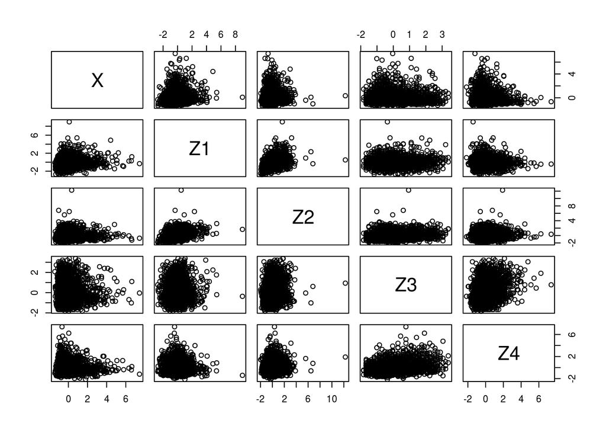

```r
Y <- datos$Y
X <- datos[, c("X","Z1","Z2","Z3","Z4")]

plot(X)
```

```r
table(Y)
```

```
## Y
##    0    1
## 2019  361
```

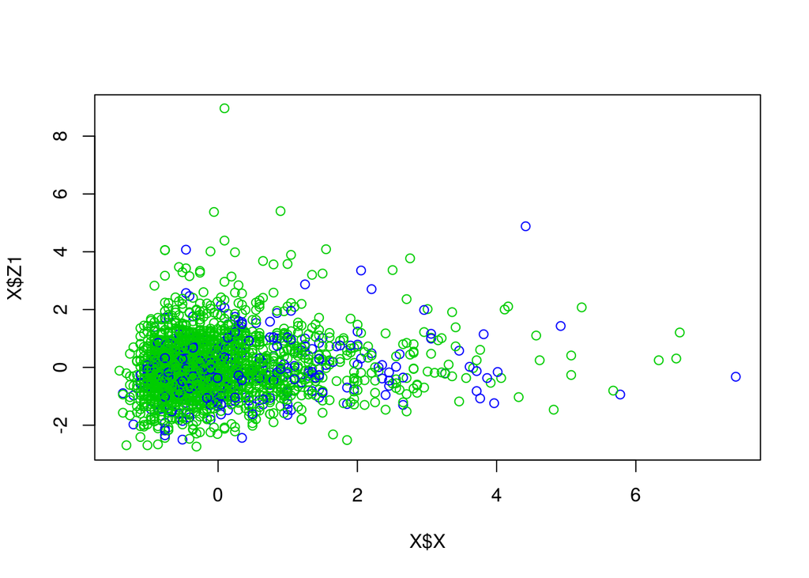

```r
plot(X$X, X$Z1, col=Y+3)
```

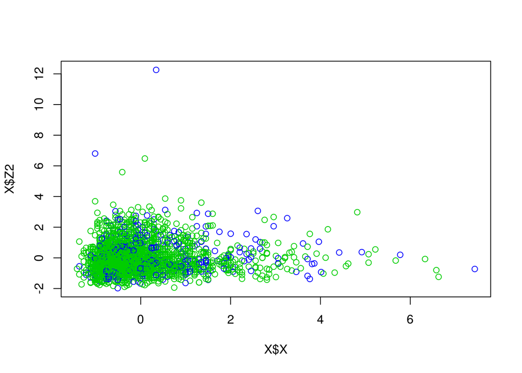

```r
plot(X$X, X$Z2, col=Y+3)
```

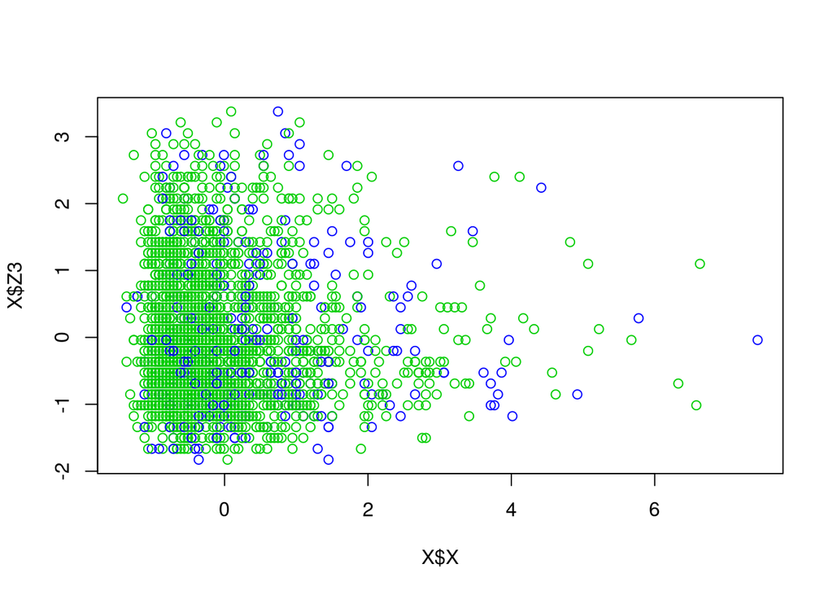

```r
plot(X$X, X$Z3, col=Y+3)
```

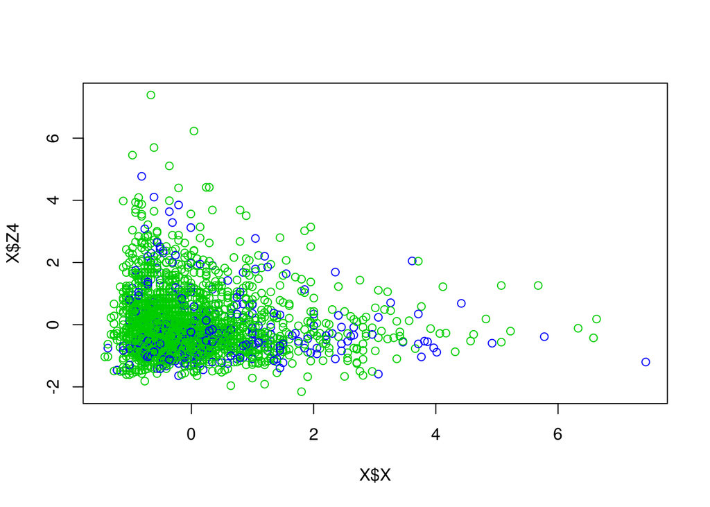

```r
plot(X$X, X$Z4, col=Y+3)
```

```r
cor(X)
```

```
##         X     Z1    Z2     Z3     Z4
## X   1.000  0.107 0.041 -0.019 -0.081
## Z1  0.107  1.000 0.362  0.036 -0.054
## Z2  0.041  0.362 1.000  0.197  0.125
## Z3 -0.019  0.036 0.197  1.000  0.301
## Z4 -0.081 -0.054 0.125  0.301  1.000
```

```r
summary(X)
```

```
##        X              Z1             Z2             Z3
##  Min.   :-1.4   Min.   :-2.7   Min.   :-2.0   Min.   :-1.8
##  1st Qu.:-0.7   1st Qu.:-0.6   1st Qu.:-0.7   1st Qu.:-0.7
##  Median :-0.3   Median :-0.1   Median :-0.2   Median :-0.2
##  Mean   : 0.0   Mean   : 0.0   Mean   : 0.0   Mean   : 0.0
##  3rd Qu.: 0.3   3rd Qu.: 0.5   3rd Qu.: 0.5   3rd Qu.: 0.6
##  Max.   : 7.4   Max.   : 9.0   Max.   :12.3   Max.   : 3.4
##        Z4
##  Min.   :-2.2
##  1st Qu.:-0.7
##  Median :-0.2
##  Mean   : 0.0
##  3rd Qu.: 0.4
##  Max.   : 7.4
```

*Notemos que los datos en las $X$s (covariables) han sido ya estandarizados. Esta es una practica comun para el ajuste de modelos $GLM$.*

La implementacion de los modelos que usaremos en esta sesion require de los paqutes `broom` y `biglm` de R:

```
install.packages("broom")
install.packages("biglm")
```

- El paquete `broom` convierte los resultados de un modelo en la forma de un `data.frame`, de forma que podemos recuperar sus resultados por componente rapida y sencillamente (noten que esta funcionalidad solo es valida cuando tenemos modelos con salidas “tipicas” de R).
- El paquete `biglm` implementa modelos lineales generalizados con una reduccion significativa del uso de memoria, por lo que puede implementarse en bases de datos “grandes”.

### Datos `train` y `test`

Construimos la muestra de `entrenamiento` (o `train`) y la muestra de `prueba` (o `test`).

```r
indice1 <- which(Y==1)
indice0 <- which(Y==0)

length(indice1)
```

```
## [1] 361
```

```r
length(indice0)
```

```
## [1] 2019
```

```r
set.seed(33)
indice1train <- sample(indice1,300,replace=FALSE)
indice0train <- sample(indice0,1800,replace=FALSE)

Y.train <- Y[c(indice1train,indice0train)]
Y.test <- Y[-c(indice1train,indice0train)]
X.train <- X[c(indice1train,indice0train),]
X.test <- X[-c(indice1train,indice0train),]
```

### Aprendizaje estadistico

```r
table(Y.train)
```

```
## Y.train
##    0    1
## 1800  300
```

```r
train <- cbind(Y.train,X.train)
summary(train)
```

```
##     Y.train           X              Z1             Z2
##  Min.   :0.00   Min.   :-1.4   Min.   :-2.7   Min.   :-2.0
##  1st Qu.:0.00   1st Qu.:-0.7   1st Qu.:-0.6   1st Qu.:-0.7
##  Median :0.00   Median :-0.3   Median :-0.1   Median :-0.2
##  Mean   :0.14   Mean   : 0.0   Mean   : 0.0   Mean   : 0.0
##  3rd Qu.:0.00   3rd Qu.: 0.3   3rd Qu.: 0.6   3rd Qu.: 0.5
##  Max.   :1.00   Max.   : 6.6   Max.   : 9.0   Max.   :12.3
##        Z3             Z4
##  Min.   :-1.8   Min.   :-2.2
##  1st Qu.:-0.7   1st Qu.:-0.7
##  Median :-0.2   Median :-0.2
##  Mean   : 0.0   Mean   : 0.0
##  3rd Qu.: 0.6   3rd Qu.: 0.4
##  Max.   : 3.4   Max.   : 7.4
```

```r
head(train)
```

```
##      Y.train      X     Z1       Z2     Z3     Z4
## 1039       1 -0.763 -0.413 -1.02586 -0.201 -1.034
## 889        1  0.041 -1.628 -0.32542 -0.689 -1.248
## 1115       1 -0.260  0.022 -0.28789 -1.014  0.079
## 2208       1  0.092  0.352 -0.38795 -0.527 -0.530
## 1975       1 -0.814 -0.338 -0.00021 -0.039 -0.409
## 1141       1  4.920  1.432  0.37503 -0.852 -0.596
```

```r
# GLM convencional
formula <- Y.train~1+X+Z1+Z2+Z3+Z4

# Logit
logit.fit <- glm(formula,
                   data=train,
                   family=binomial(link = "logit"))
summary(logit.fit)
```

```
##
## Call:
## glm(formula = formula, family = binomial(link = "logit"), data = train)
##
## Deviance Residuals:
##    Min      1Q  Median      3Q     Max
## -1.395  -0.576  -0.506  -0.438   2.421
##
## Coefficients:
##             Estimate Std. Error z value Pr(>|z|)
## (Intercept) -1.85271    0.06548  -28.29  < 2e-16 ***
## X            0.29547    0.05452    5.42    6e-08 ***
## Z1          -0.26500    0.07079   -3.74  0.00018 ***
## Z2           0.19719    0.06343    3.11  0.00188 **
## Z3          -0.00816    0.06868   -0.12  0.90542
## Z4          -0.19895    0.07334   -2.71  0.00668 **
## ---
## Signif. codes:  0 '***' 0.001 '**' 0.01 '*' 0.05 '.' 0.1 ' ' 1
##
## (Dispersion parameter for binomial family taken to be 1)
##
##     Null deviance: 1722.5  on 2099  degrees of freedom
## Residual deviance: 1672.6  on 2094  degrees of freedom
## AIC: 1685
##
## Number of Fisher Scoring iterations: 4
```

```r
# Probit
probit.fit <- glm(formula,
                   data=train,
                   family=binomial(link = "probit"))
summary(probit.fit)
```

```
##
## Call:
## glm(formula = formula, family = binomial(link = "probit"), data = train)
##
## Deviance Residuals:
##    Min      1Q  Median      3Q     Max
## -1.333  -0.578  -0.507  -0.435   2.456
##
## Coefficients:
##             Estimate Std. Error z value Pr(>|z|)
## (Intercept) -1.09527    0.03485  -31.42  < 2e-16 ***
## X            0.17085    0.03149    5.43  5.8e-08 ***
## Z1          -0.14422    0.03826   -3.77  0.00016 ***
## Z2           0.10540    0.03575    2.95  0.00320 **
## Z3          -0.00719    0.03718   -0.19  0.84667
## Z4          -0.10079    0.03864   -2.61  0.00910 **
## ---
## Signif. codes:  0 '***' 0.001 '**' 0.01 '*' 0.05 '.' 0.1 ' ' 1
##
## (Dispersion parameter for binomial family taken to be 1)
##
##     Null deviance: 1722.5  on 2099  degrees of freedom
## Residual deviance: 1672.3  on 2094  degrees of freedom
## AIC: 1684
##
## Number of Fisher Scoring iterations: 4
```

```r
## bigGLM
#require("biglm")
## Logit
#logit.bigfit <- bigglm(formula,
#                   data=train,
#                   family=binomial(link = "logit"),
#                   chunksize = 10, sandwich = TRUE)
#summary(logit.bigfit)
## Probit
#probit.bigfit <- bigglm(formula,
#                   data=train,
#                   family=binomial(link = "probit"))
#summary(probit.bigfit)
```

Ahora realizamos algunas predicciones…

```r
# Test
test <- cbind(Y.test,X.test)
summary(test)
```

```
##      Y.test           X              Z1             Z2
##  Min.   :0.00   Min.   :-1.4   Min.   :-2.1   Min.   :-1.74
##  1st Qu.:0.00   1st Qu.:-0.7   1st Qu.:-0.7   1st Qu.:-0.70
##  Median :0.00   Median :-0.4   Median :-0.1   Median :-0.23
##  Mean   :0.22   Mean   :-0.1   Mean   :-0.1   Mean   :-0.03
##  3rd Qu.:0.00   3rd Qu.: 0.1   3rd Qu.: 0.4   3rd Qu.: 0.47
##  Max.   :1.00   Max.   : 7.4   Max.   : 4.1   Max.   : 3.05
##        Z3              Z4
##  Min.   :-1.83   Min.   :-1.6
##  1st Qu.:-0.69   1st Qu.:-0.7
##  Median :-0.20   Median :-0.2
##  Mean   : 0.10   Mean   :-0.1
##  3rd Qu.: 0.77   3rd Qu.: 0.3
##  Max.   : 2.89   Max.   : 5.7
```

```r
head(test)
```

```
##    Y.test     X     Z1    Z2     Z3     Z4
## 5       0  0.19  0.562 -0.10  0.612  0.784
## 12      1 -0.16  0.157  2.45  0.124  0.396
## 18      0 -0.71 -1.493  1.94  2.401  0.426
## 29      1 -0.11 -0.758 -0.94 -0.201 -0.083
## 44      0 -0.76  0.022 -0.34 -0.039  0.426
## 50      0 -0.96  0.052  0.15 -0.689  0.093
```

```r
# Prediccion

# Logit
logit.test <- as.data.frame(predict(logit.fit, test, type="response"))
summary(logit.test)
```

```
##  predict(logit.fit, test, type = "response")
##  Min.   :0.05
##  1st Qu.:0.11
##  Median :0.13
##  Mean   :0.15
##  3rd Qu.:0.17
##  Max.   :0.63
```

```r
# Probit
probit.test <- as.data.frame(predict(probit.fit, test, type="response"))
summary(probit.test)
```

```
##  predict(probit.fit, test, type = "response")
##  Min.   :0.04
##  1st Qu.:0.11
##  Median :0.13
##  Mean   :0.15
##  3rd Qu.:0.17
##  Max.   :0.61
```

### Estimacion por remuestreo

En este apratado implementamos un procedimiento de remuestro sobre el aprendizaje con los datos de `entrenamiento` empleando el paquete `broom`.

Con el siguiente script generamos un `data.frame` con los valores estimados de los coeficientes de los modelos con base para cada una de las muestras `boostrap`.

```r
require("dplyr")
require("broom")
boot.sample <- 100

# Logit
logit.boot <-train %>%
              bootstrap(boot.sample) %>%
              do(tidy(glm(formula, ., family=binomial(link = "logit"))))
head(logit.boot)
```

```
## Source: local data frame [6 x 6]
## Groups: replicate [1]
##
##   replicate        term estimate std.error statistic  p.value
##       <int>       <chr>    <dbl>     <dbl>     <dbl>    <dbl>
## 1         1 (Intercept)   -1.842     0.066    -28.09 1.3e-173
## 2         1           X    0.362     0.051      7.13  1.0e-12
## 3         1          Z1   -0.309     0.072     -4.31  1.6e-05
## 4         1          Z2    0.185     0.063      2.95  3.1e-03
## 5         1          Z3   -0.018     0.069     -0.26  7.9e-01
## 6         1          Z4   -0.079     0.071     -1.11  2.7e-01
```

```r
# Probit
probit.boot <-train %>%
              bootstrap(boot.sample) %>%
              do(tidy(glm(formula, ., family=binomial(link = "probit"))))
head(probit.boot)
```

```
## Source: local data frame [6 x 6]
## Groups: replicate [1]
##
##   replicate        term estimate std.error statistic  p.value
##       <int>       <chr>    <dbl>     <dbl>     <dbl>    <dbl>
## 1         1 (Intercept)   -1.085     0.035     -31.4 8.6e-217
## 2         1           X    0.134     0.033       4.0  5.7e-05
## 3         1          Z1   -0.105     0.038      -2.8  5.6e-03
## 4         1          Z2    0.134     0.034       4.0  7.3e-05
## 5         1          Z3    0.047     0.035       1.3  1.8e-01
## 6         1          Z4   -0.071     0.037      -1.9  5.5e-02
```

# Referencias

- Introduccion a “boostrap” del libro *An Introduction to the Bootstrap* de B. Efron & R. Tibshirani (1993) [[liga]](https://www.hms.harvard.edu/bss/neuro/bornlab/nb204/statistics/bootstrap.pdf)